# ABC Fund: More Than Market Beta

Peer performance insights for the 2027 conference

Kieron Maseko (26572982)

November 2026

## 2 The industry is mostly market beta

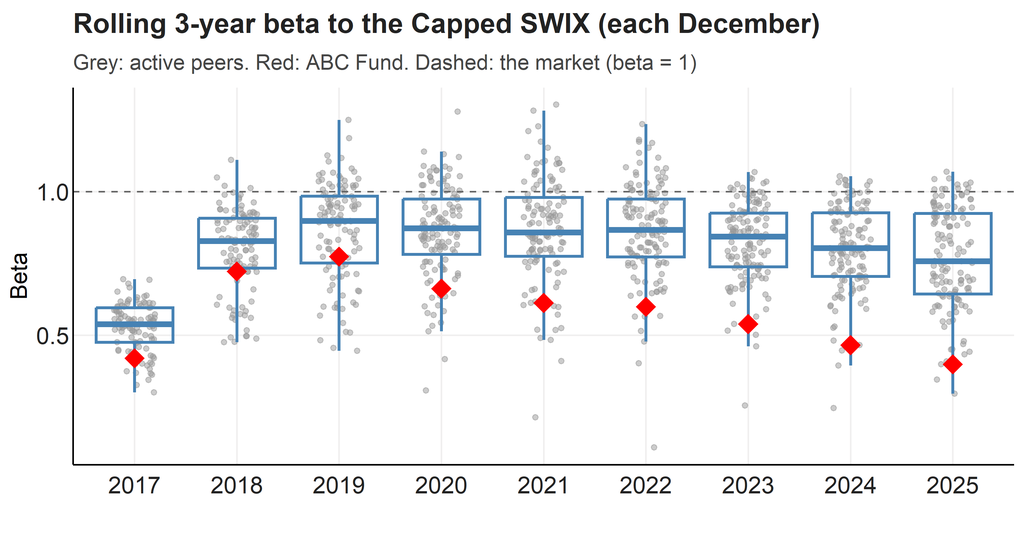

## 3 ABC follows its own path

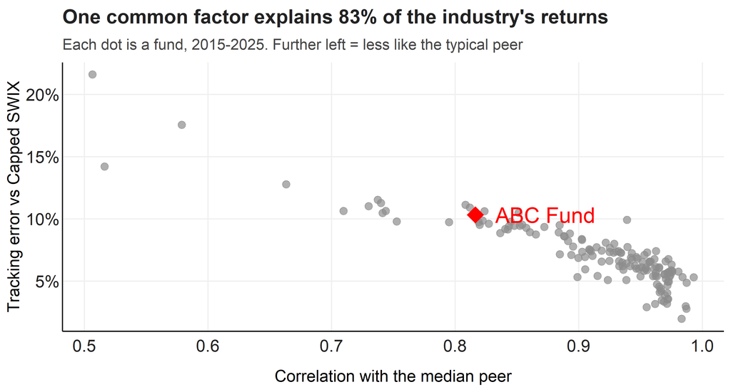

## 4 Consistently ahead of the pack

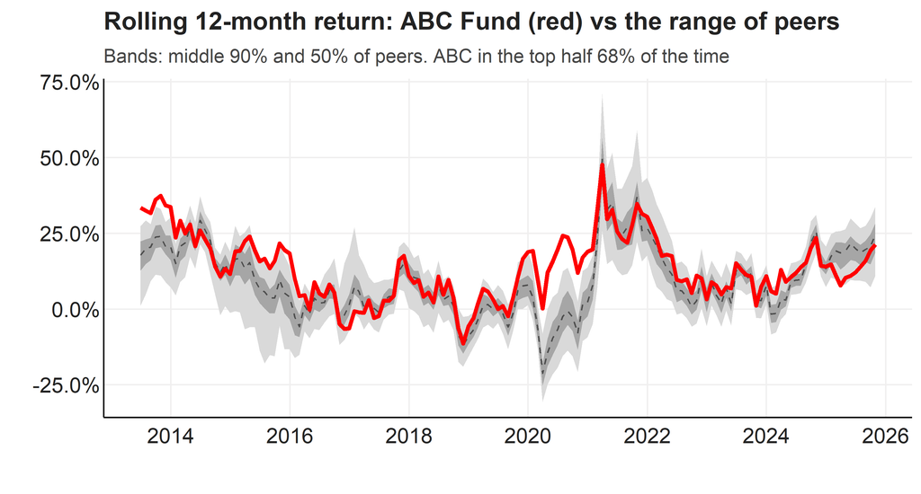

## 5 Track record since 2015

| Measure | ABC Fund | Typical peer | Capped SWIX |
| --- | --- | --- | --- |
| Annualised return | 11.9% | 7.8% | 9.0% |
| Annualised volatility | 11.1% | 12.3% | 15.3% |
| Return per unit of risk | 1.07 | 0.64 | 0.59 |
| Rolling 3-year beta (median) | 0.61 | 0.83 | 1.00 |
| Alpha (annualised, median) | 7.0% | 1.2% | 0.0% |

January 2015 to October 2025, monthly returns. Typical peer = median active manager each month.

## 6 Where the edge comes from: falling markets

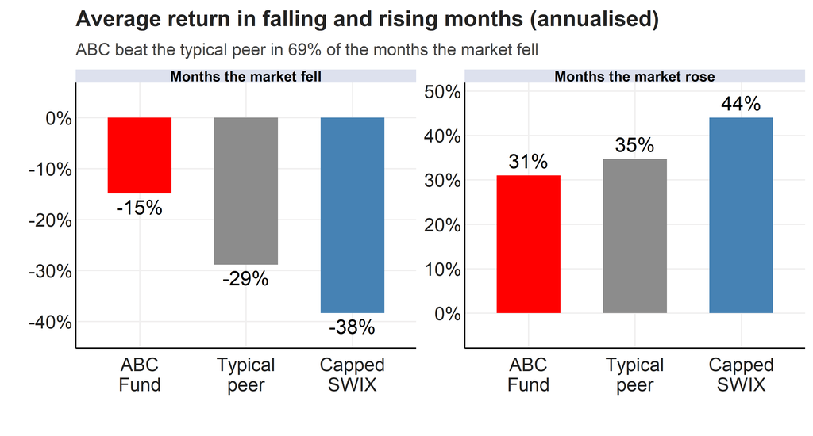

## 7 Does high market dispersion reward ABC?

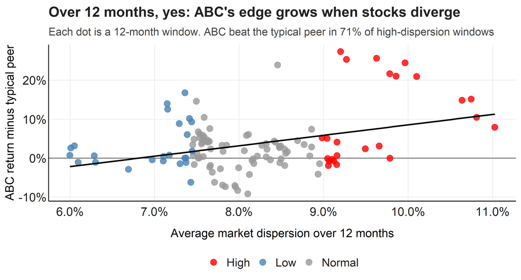

## 8 Dispersion: what we can and cannot say

- **Over a year or more, the claim holds.** In the most dispersed 12-month periods ABC beat the typical peer by 9.6%, against 2% in other periods.
- **Month to month, it does not.** In the single most dispersed months ABC actually lagged its peers (it beat them in only 38% of those months).
- **Most of the evidence comes from one period (2020-2022).** We suggest presenting dispersion as supporting colour, and leading with ABC’s low beta and downside protection.

## 9 Why ABC belongs in client portfolios

- **Something other than market beta:** clients can buy beta cheaply in an index fund; ABC offers a different return stream.
- **A better ride:** higher returns than the typical peer and the benchmark since 2015, with less volatility.
- **Protection when it matters:** ABC has done best when markets fall, which is when clients need it most.
- **Caveats:** past performance does not guarantee future returns; the analysis uses returns only and covers 2015-2025, and ABC tends to lag in strong rising markets.